# Analysis of Country Music Lyrics, 1960 - 2010

Sean, Cambri, Hailey

April 8, 2019

### Abstract

In this project, the authors analyze 2500 charted and uncharted country songs evenly distributed across a period of time from 1960 until 2010. Using supervised and unsupervised machine learning methods—namely, classification and Structural Topic Modeling, respectively—the authors interrogate the process of song ranking, a form of canonization that influences the formation of genres, audience perception of songs, and the ways that composers write their songs. Using these and other data analysis methods, the authors seek to understand how charted and uncharted country songs' lyrical and structural features change over time and if the presentation of their features can help to distinguish charted and uncharted songs. The authors also seek to discover topics and themes from the country music lyric data, hypothesizing that topics may present differently between charted and uncharted songs. Even though classification and topic modeling do not ultimately show major differences between charted and unchated country songs, the results of such methods demonstrate that, in terms of the features identified and songs studied, song ranking is fairly arbitrary and perhaps influenced by other types of information, such as how/when a song is packaged and released. Moreover, the present research also demonstrates a need for further study—to discover more features (perhaps more musical rather than lyrical) for analysis and to improve and expand upon the current methods used.

### Introduction

Music is something many people are passionate about. Studying lyrics is one of the many ways to better understand music. Country music is one of most unique genres lyrically, so this project sets out to better understand country music lyrics. This paper aims to establish if there are certain elements of a country song, lyrically or structurally that distinguish hit songs from songs that don’t make it on top charts. Furthermore, do these elements that “make or break” a song change over time between 1960 and 2010? While researching, we also attempted to implement a machine learning classifier to determine: 1. If a machine model could accurately predict whether or not a song charted based on a set of features it was given, and, 2. Which features most help it predict whether songs are charted or not. We hypothesized that there may be distinguishing elements, including structural simplicity, repetition in both individual words as well as longer units such as choruses, and song duration. In particular, we imagined that top songs would, in general, demonstrate greater levels of structural simplicity, greater repetition, and shorter duration. This project corpus contains 25 songs from top 100 song charts from each decade between 1960 and 2010, according to Playback.fm, for a total of 1250 songs. The second corpus, for comparison purposes, includes 1250 uncharted songs from albums of the same charted songs. This research only explores country songs, and only songs between 1960-2010. The research does not get anymore recent than 2010 to avoid incomplete decades and maintain a manageable pool size. The structure of this paper is as follows: Background Research, Methodology, Observations, Conclusion, and Works Cited.

### Background Research

This research is broadly founded in the idea of canons—seeking to understand why some songs make it onto charts over time and why others don't. Much like Katherine Bode suggests in her own Digital Humanities work, we built our own archive, and we did so with a mind toward interrogating cultural systems of value that position some works of art as better than others.

Looking at previous research done on music analysis, there is a lack of research on top country songs and what could be distinguishing those hit songs. There has been plenty of country music lyrical analysis, that has either been done on a casual scale, or coded research that focuses in on a niche component of country music. For example, an article from *Nashville Scene*, entitled “[A Breakdown of the Lyrical Content of Billboard's Top 20 Country Songs](https://www.nashvillescene.com/music/article/13049979/a-breakdown-of-the-lyrical-content-of-billboards-top-20-country-songs)” was an informal analysis looking for similar themes between Billboard’s Top 20 songs (Black). In “[What Happened to Country Music](https://medium.com/@plewis67/what-happened-to-country-music-300cf8303430),” a *Medium* article, Peter Lewis hand codes country music into particular thematic categories (“it’s all over, it’s not working out, love and devotion, and the right way to live”) and then examines those themes’ distribution among a dataset of country songs over time (Lewis). Both of these articles, while applied to shorter datasets, give us models to validate results from topic modeling, an unsupervised machine learning method that returns clusters of words and their probabilities for occurring across a dataset.

This research fills the gap of a large-scale lyrical analysis of country music. While other research may have looked at a niche component of country songs, or focused on country music as a whole, this work has focused on songs from a period of 50 years, and strives to understand what distinguishes hit songs from non-hit songs. Furthermore, this research focuses on country music, a genre that is normally overlooked for lyrical analysis, in comparison to genres like pop or rap.

### Methodology

As mentioned previously, we employed a Python script to gather 25 charted songs from each decade between 1960-2010, according to Playback.fm, totalling 1250 songs. During the metadata acquisition stage, we were also asking the script to pick up songs that were not charted but on the same release (A/B side, other tracks on a full-length album). In this way, we built a control group (uncharted songs) and a test group (charted songs).

While the script was operating, it was attempting to grab lyrics for the charted songs and metadata, such as whether the song was from an album or single, its album/single release name, and its duration. Because early years did not reliably return lyrics and metadata (for such reasons as copyright protections on information and a general lack of information on lesser known and/or older songs and artists), we capped each year at 50 songs (25 charted and 25 uncharted). In total, 2500 songs will be analyzed. When we transitioned to R for our data analysis, we also decided to manipulate our script to remove any duplicates. So, if a song appeared in one year’s charted or uncharted category, it would be excluded from either of those categories in later years. While one could make the case that this methodological choice eliminates the element of chance and downplays the popularity of certain songs over time (demonstrated in their charting over 2 or 3 years perhaps), we also did not want our lyric and structural data to be skewed by the dominance of certain songs or, even, artists.

Some of the first measurements used to analyze the lyrics included analyzing song structure through Levenshtein Distance, POS Tagging, and Type-Token Ratio. We used Levenshtein Distance, a metric that finds the minimum number of edits to turn one character string into another, to gauge repetition in our songs. First, we calculated mean Levenshtein Distance scores per stanza per song, and then we calculated the proportion of repetitive stanzas (determined by those less than one standard deviation from the mean Levenshtein Distance) to non-repetitions. In the example below, a song that has three stanzas, we would give the song a repetition score of .3333 because 1 out of a possible 3 stanza pairings demonstrated repetition.

```
## # A tibble: 1 x 6
## # Groups:   Doc [1]
##     Doc Index1 String1                 Index2 String2                  Dist
##   <int>  <int> <chr>                    <int> <chr>                   <dbl>
## 1    47      2 " Right about now, the~      3 " Right about now, the~     1
```

```
## # A tibble: 3 x 6
## # Groups:   Doc [1]
##     Doc Index1 String1                 Index2 String2                  Dist
##   <int>  <int> <chr>                    <int> <chr>                   <dbl>
## 1    47      1 "There are twenty-thre~      2 " Right about now, the~   142
## 2    47      1 "There are twenty-thre~      3 " Right about now, the~   141
## 3    47      2 " Right about now, the~      3 " Right about now, the~     1
```

```
## [1] 0.3333333
```

POS tagging was used to determine, similarly to type token ratio, ratios of each unique pronoun type over the total pronouns used in each song. Then, the greatest ratio was used to determine which pronoun was most used to “tell” each song’s story.

After making mathematical observations about each song in our set, we arrived at a set of lyrical and structural features that we could use to distinguish between songs that appeared at different times and songs that charted and did not. In our observations section, we discuss some of the relationships between different features we were able to observe. Seeing how different features changed over time and between charted and uncharted songs encouraged us to attempt to train a machine learning classifier. The goal was to create a classifier that can distinguish hit songs from uncharted songs. For our first model, our “classes” include charting and not charting (true and false). Our features are listed below:

1. Duration
2. Number of Stanzas
3. Year Charted
4. Proportion of Repeated Stanzas to Total Possible Repetitions
5. Relatively Highest Pronoun Used
6. Type-Token Ratio

To determine what machine learning model best fit our data set, we needed to encode some of our categorical variables and then compare some linear and non-linear models to gauge their performance. We compared six different models (K-Nearest Neighbor, Support Vector Machines - Linear, K-SVM - Radial, Logistic Regresssion, Naive Bayes, and Random Forest Decision Trees) and ran a 5-fold validation to see which model performed best. In his section on predicting between fiction and non-fiction works in *Enumerations*, Andrew Piper employs a similar validation scheme, using a 10-fold split. “What this means in practice,” Piper explains, “is that I randomly divide the corpus into a 90 - 10 split ten times, where 90% of the documents are used to train the algorithm and the unseen 10% are used to test its reliability” ("The Coherence of Fictionality"). One of the major affordances of this particular validation scheme, moreover, is that it gives “each document [in a corpus] an opportunity to be in the test set” ("The Coherence of Fictionality"). Because our dataset is relatively small, we chose 5 folds, which results in a similar procedure as Piper describes, except that our validation scheme trains and tests on 5 random 80 - 20 splits. We ran our validation scheme 100 times and measured the mean, minimum, maximum, and standard deviation of each fold during each run. Examining a table of results below and a plot of the mean accuracy scores for each fold for each model (the plot mistakenly does not list all classifiers used, so please remember those listed above), we determined that Support Vector Machines with a Linear kernel (a linear model) and Support Vector Machines with a Radial kernel (a non-linear model) performed best. For our purposes, we decided, then, to choose the K-SVM model for future analyses and observations, which are described in further detail in our observations section. It should be noted, though, that no model performed sufficiently well at the classification task we performed.

```
## # A tibble: 6 x 5
##   method    mean_accuracy min_acc max_acc sd_acc
##   <chr>             <dbl>   <dbl>   <dbl>  <dbl>
## 1 knn_fold          0.521   0.333   0.681 0.0570
## 2 ksvm_fold         0.579   0.403   0.746 0.0568
## 3 log_fold          0.577   0.394   0.75  0.0588
## 4 nb_fold           0.568   0.352   0.75  0.0581
## 5 rf_fold           0.547   0.375   0.704 0.0566
## 6 svm_fold          0.580   0.394   0.75  0.0580
```

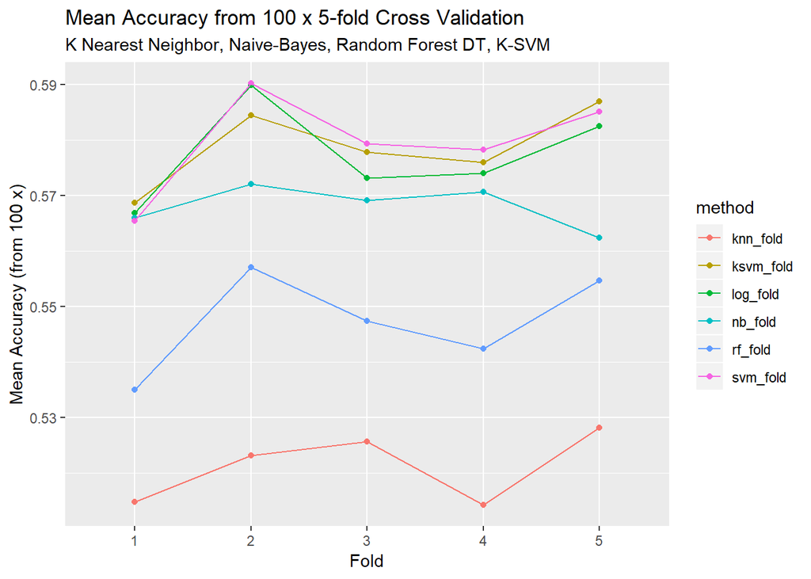

Because we are interested in how country songs change over time and whether or not those changes manifest differently between charted and uncharted songs, we feel that, along with classification, topic modeling could help us address these aims. In the words of literary scholar and digital humanist Paul Barrett, Topic Modeling is:

"…a form of unsupervised machine learning. It is a kind of text mining that doesn’t search for particular, predetermined content, but instead ‘reads’ an entire corpus and extracts a set of topics. It’s unclear, and a point of debate, whether the topics are read / discovered from the corpus or whether the topics are ‘asserted’ as a description of the corpus."

One hypothesis we have at this stage is that perhaps charted and uncharted songs may present slightly different topics from one another. Essentially, we wonder if, to write a top song, one has to write about a particular set of topics. According to much of the literature on topic modeling, at the moment, there are two main methods: Latent Dirichlet Allocation (LDA) and Structural Topic Modeling (STM). In “A Review of Best Practice Recommendations for Text Analysis in R,” the authors explain the primary differences between these two approaches. All topic models assume “that a document is a mixture of topics where each word in the document belongs to a single topic”; however, STM, unlike LDA, “uses a regression framework to understand whether [other features about documents] influence the content” (Banks et al. 449). Knowing that STM is a more robust topic modeling method, we decided to use it. We also decided to evaluate its performance on our two datasets (charted and uncharted songs) through measuring results such as semantic coherence, residuals, held-out likelihood, and exclusivity for models with 10, 20, 40, 50, 60, 70, 80, 100, 120, and 150 topic clusters. In measuring each model’s performance, we also iterated a fixed number per model to get a range of performance scores per model. The results of our evaluations can be seen below.

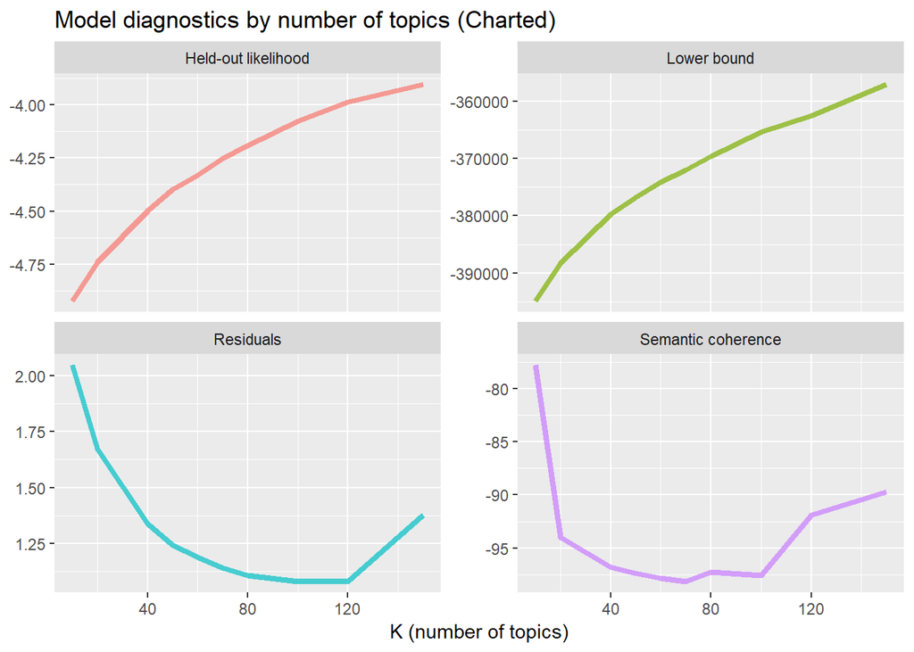

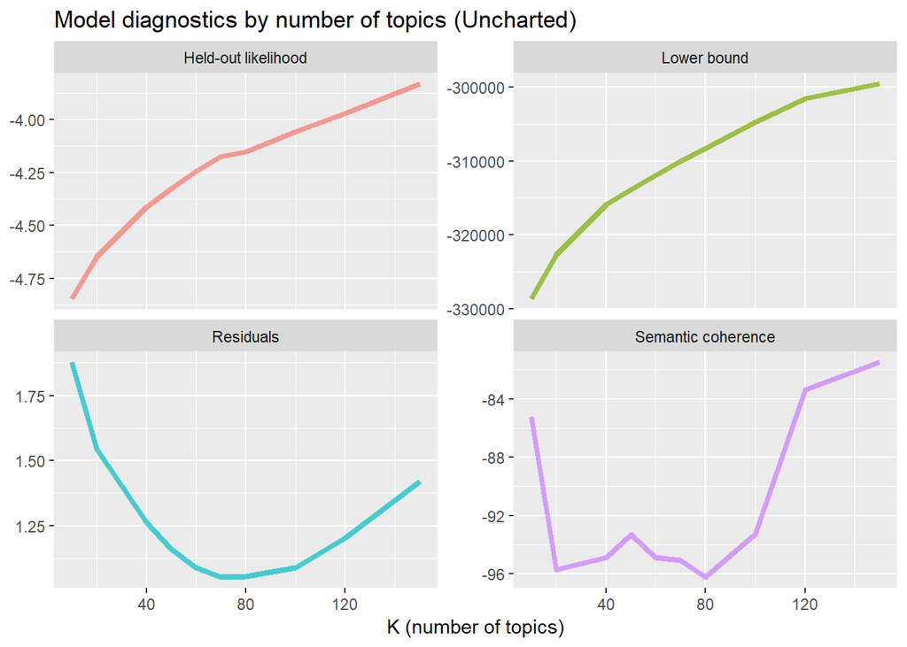

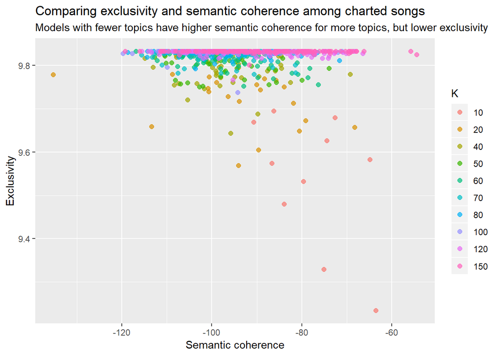

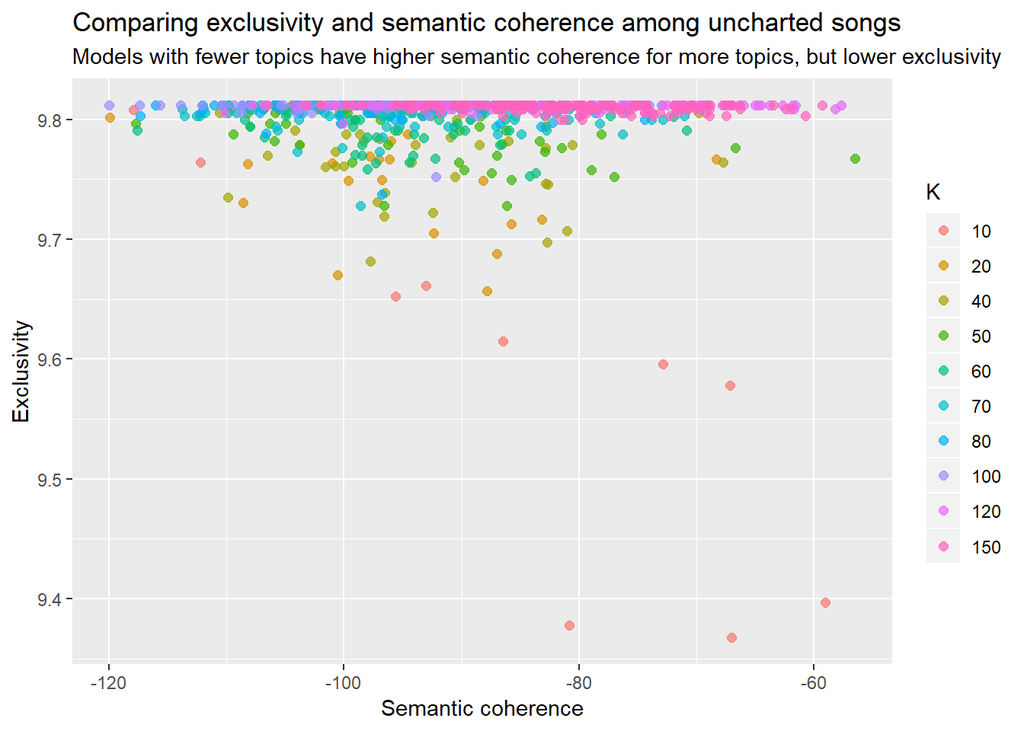

After examining the different charts, we determined that we would get the best results from the topic model that builds 120 topics (clusters) for both charted and uncharted songs. The contents and “fit” of these topics will be described in our observations below.

### Observations

Overall, from all of our methods, we realized that there is little difference between charted and uncharted songs lyrically and structurally. They both follow similar patterns.

In terms of duration and repetition alone, charted and uncharted songs are very similar. See the mean and standard deviations for duration and proportion of repeated stanzas below (0 = uncharted, 1 = charted).

```
## # A tibble: 2 x 3
##   chart mean_dur sd_dur
##   <fct>    <dbl>  <dbl>
## 1 0         189.   42.3
## 2 1         196.   40.7
```

```
## # A tibble: 2 x 3
##   chart mean_rep sd_rep
##   <fct>    <dbl>  <dbl>
## 1 0        0.158  0.108
## 2 1        0.164  0.102
```

Over time, these features change, but charted and uncharted songs follow remarkably similar trajectories.

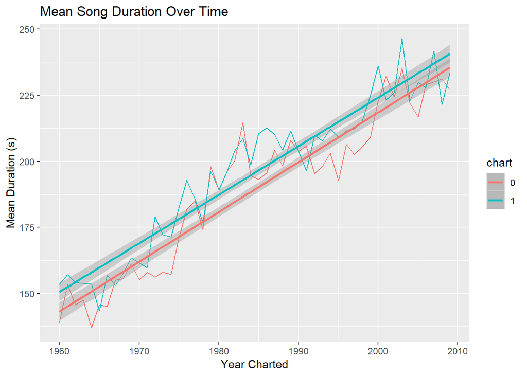

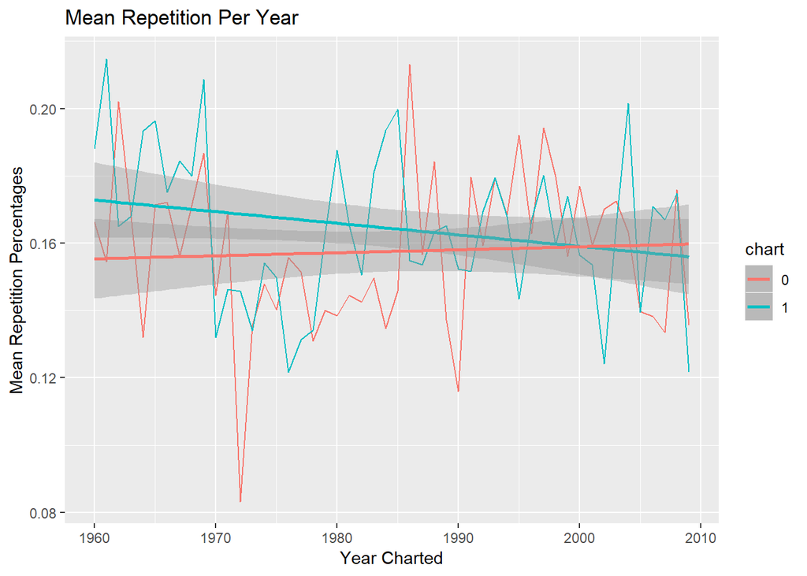

What we've done is plot the mean duration and repetition per year for charted and uncharted songs and then overlay linear regression lines encapsulating *a* relationship between duration and time and repetition and time, respectively and for charted and uncharted songs. Overall, over time, charted songs are slightly longer in our set and slightly more repetitive; however, these differences, as we show, are not significant enough to allow a model to achieve a sufficient level of accuracy in a classification task.

Similarly, pronoun usage was fairly similar between charted and uncharted songs. The parts of speech for charted and uncharted country songs are mostly similar. Most songs tell their stories from the 3rd person perspective. The trend in high third person usage, moreover, does not alter much with time. This was not necessarily expected. Such a result, however, is easy to understand because we imagine that songs told from this perspective may be more relatable.

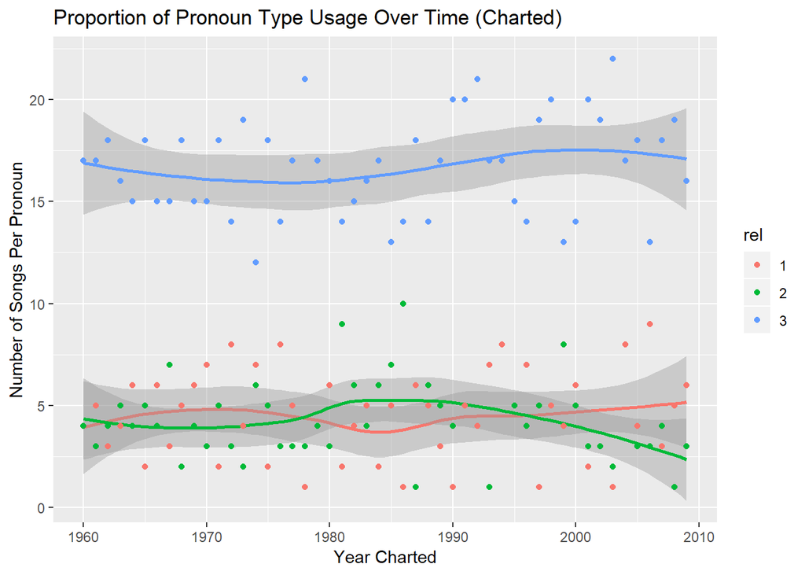

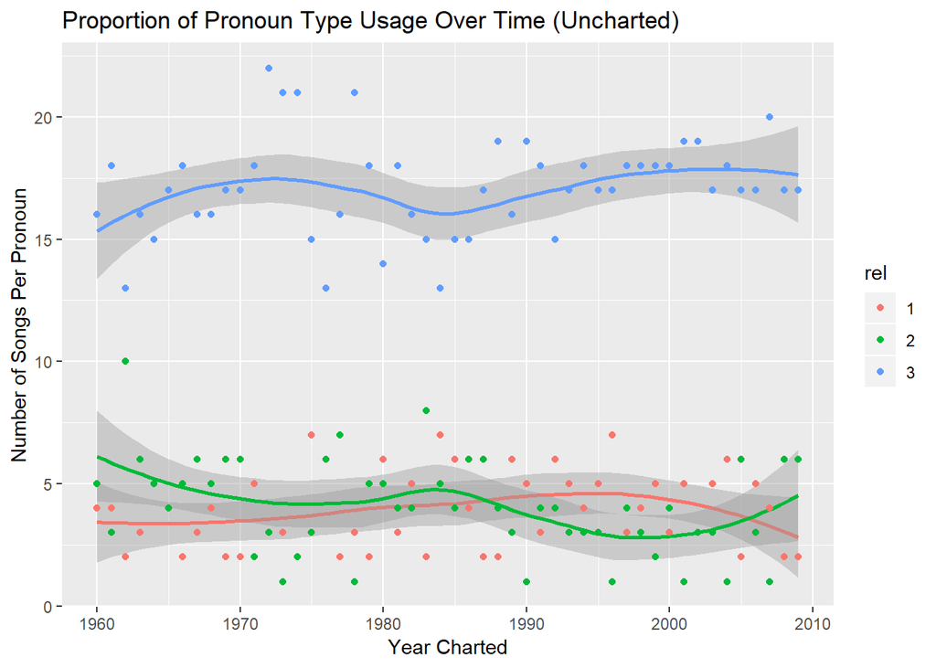

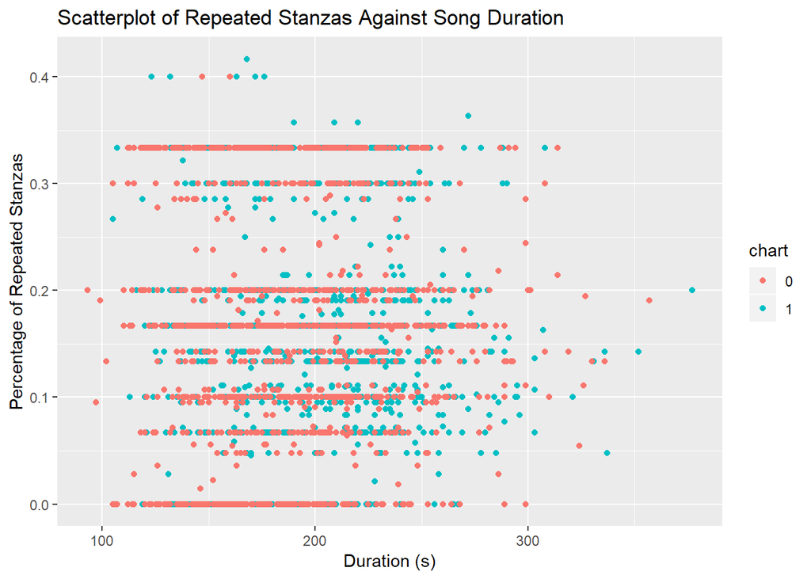

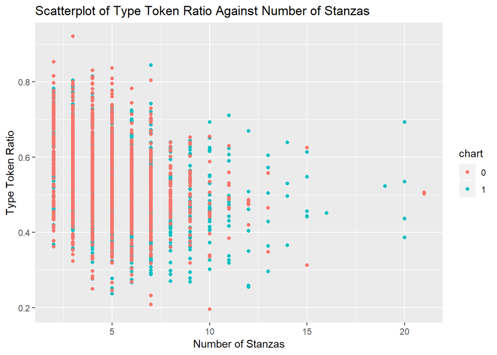

```
## # A tibble: 5 x 5
##    fold mean_acc min_acc max_acc sd_acc
##   <int>    <dbl>   <dbl>   <dbl>  <dbl>
## 1     1    0.716   0.652   0.756 0.0167
## 2     2    0.714   0.656   0.756 0.0170
## 3     3    0.716   0.678   0.758 0.0173
## 4     4    0.712   0.666   0.754 0.0186
## 5     5    0.714   0.662   0.76  0.0189
```

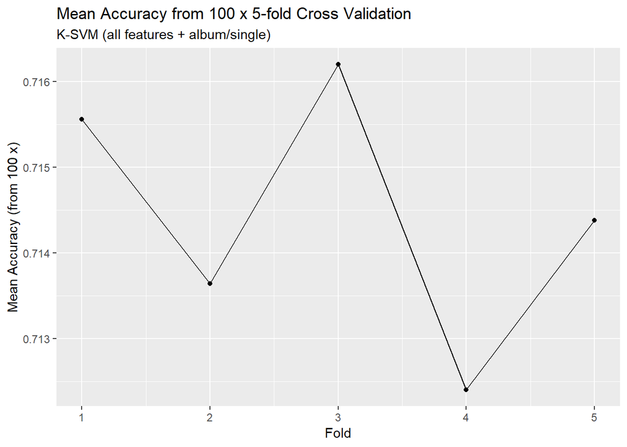

We also attempted to see if word feature use could help our classifier improve. Our results for these features were similar to those we received with the more lyrical and structural features.

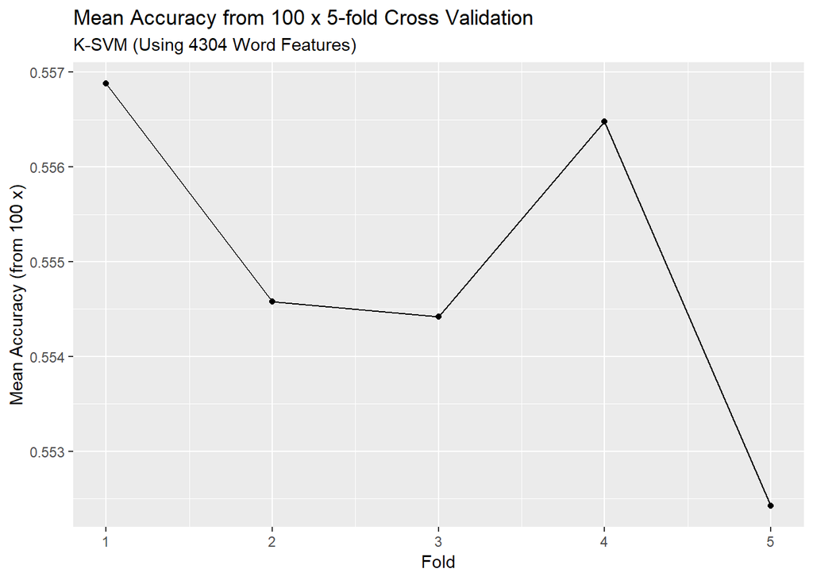

```
## # A tibble: 5 x 5
##    fold mean_acc min_acc max_acc sd_acc
##   <int>    <dbl>   <dbl>   <dbl>  <dbl>
## 1     1    0.557   0.52    0.614 0.0178
## 2     2    0.555   0.502   0.592 0.0170
## 3     3    0.554   0.506   0.62  0.0195
## 4     4    0.556   0.518   0.6   0.0180
## 5     5    0.552   0.512   0.6   0.0173
```

```
## [1] 0.554956
```

So what does this tell us? Is our model bad? Yes and no. Our model is bad at accurately classifying between charted and uncharted songs based upon the features we provide it. However, our model is good because, as shown with many of the charts that visualize the relationships between different sets of charted and uncharted songs’ features, it turns out that the charted and uncharted songs in our dataset are not that different from one another. One of the reasons for the similarities we observed derives from the way we chose to gather our data, building our control group (uncharted songs) from songs by the same artists who released hit songs. Essentially, we are comparing a charting Taylor Swift song against a Taylor Swift song that did not chart. While we believe that such a comparison is more fair than comparing a similar song with one produced by an unknown artist, it certainly makes the task of classification difficult. Thus, knowing how similar our songs are, if our model achieved accuracy, we would be concerned about overfitting.

As a final “test” of our model’s performance, we decided to see how accurately it could learn on our set of songs from 1960-2010 (not inclusive) to make predictions about whether or not songs charted from the remaining half decade of information Playback.fm has charts of (2010 - 2015). Not expecting any dramatic changes in accuracy, we did not attempt any validation and only tested our K-SVM classifier once. Similarly to earlier runs, the model recorded a 56% accuracy, which, again, is not good. However, we did notice that our model, this time, predicted uncharted songs correctly much more often than it did charted ones (it was 85% accurate just considering uncharted songs). Without further testing and validation, we cannot say whether or not this particular observation was the result of chance. In future runs, our model could swing the other direction, predicting more correct charted observations. However, we can hypothesize that this result may occur because of the general shape of our data. Examining the distribution of songs based upon different features from this new set in comparison to our original set, we could hypothesize that the new set’s charted songs’ features are diverging from past trends the data were setting slightly more dramatically than uncharted ones. In a later project, we may be able to test this hypothesis to determine why our model seems to do better with classifying uncharted songs with the new data we’ve provided it.

```
##    y_pred
##       0   1
##   0 106  19
##   1  90  35
```

Our final test was topic modeling, and because our songs turned out to be so similar, we did not anticipate topic modeling to perform any better at helping us distinguish between charted and uncharted country songs. In fact, examining charts depicting the top 20 topics for charted and uncharted songs respectively, we see many similarities. However, we also see subtle differences.

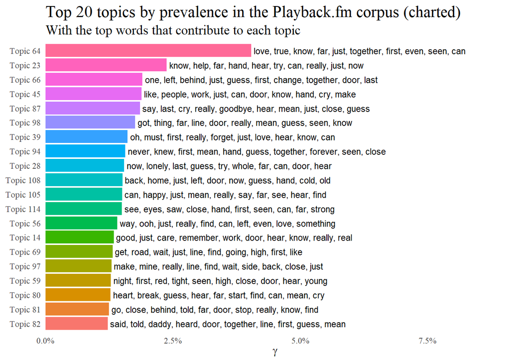

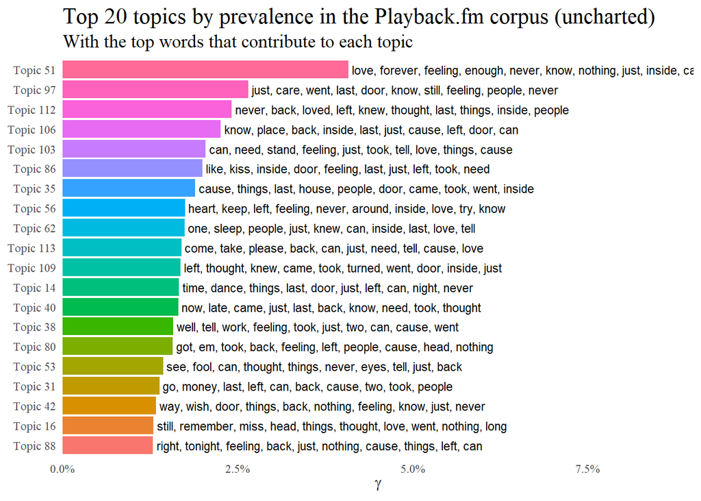

In the most prevalent topic for each set, for example, both topics have to do with love, but in different ways. Topic 64 for charted songs seems to suggest a type of love that is “true” and “first.” Conversely, the love presented in Topic 51 for uncharted songs seems to have to do with the quality of love: “forever,” “never,” “nothing,” “enough” all suggest this. The next set of about four prevalent topics seem to all in some way relate to heartbreak for each set. We can determine this general “topic” based on words such as “door,” “left,” “cry,” and “last” that appear among both charted and uncharted topics. However, when examining these sets of topics more closely, one can perhaps make the case that uncharted songs present heartbreak in a slightly more negative way. In charted songs, the word “work” appears among the heartbreak topics, which is suggestive of a type of thematic storytelling that presents a troubling scenario and then attempts to resolve it. In further research, it would be interesting to examine songs with these topics more closely to see whether charted country songs are more likely to resolve conflict and discomfort than uncharted ones.

Overall, many of the topics seem fairly unique and descriptive, but they are also highly subject to interpretation by a human. Most of them have to do with love and heartbreak, which makes sense and corroborates the topics Peter Lewis selected and then hand-coded into the songs he was observing.

### Conclusion

When given this project, our group immediately knew that we wanted to research how music has changed over time. Throughout our process, we decided to examine country music because we thought that it was going to tell a story lyrically. Country music has such strong roots and is known for being able to tell a story. We set out to see if there was a difference between charted and uncharted country songs in a span of fifty years. We thought that there would be a difference between years. Our initial thoughts about the project came up short. Machine learning methods could not help us identify differences between charted and uncharted songs. This shocked us. While we did not get the information we wanted, we got a baseline to possibly work on different directions with new data related to this project and with different genres of music. For example, in the future, it would be helpful to analyze the actual music to see if melodic and harmonic patterns play a role in the popularity of certain songs over others. It would also be interesting to analyze rock music and to see how musical and lyrical patterns and structures have changed from The Beatles to Led Zepplin to Nirvana. Maybe things haven’t changed as much as we, and perhaps others, think they have.

### Works Cited

Banks, George C., Haley M. Woznyj, Ryan S. Wesslen, and Roxanne L. Ross. “A Review of Best Practice Recommendations for Text Analysis in R (and a User-Friendly App).” *Journal of Business and Psychology*, vol. 33, no. 4, 2018, pp. 445–59. [https://doi.org/10.1007/s10869-017-9528-3](https://link.springer.com/article/10.1007%2Fs10869-017-9528-3).

Barrett, Paul. "DHSI: Introduction to Machine Learning." Digital Humanities Summer Institute, 07 June 2018, University of Victoria, Victoria, BC. Workshop.

Black, Casey. “A Breakdown of the Lyrical Content of Billboard's Top 20 Country Songs.” *Nashville Scene*, www.nashvillescene.com/music/article/13049979/a-breakdown-of-the-lyrical-content-of-billboards-top-20-country-songs.

Bode, Katherine. "Introduction: Quesitons and Opportunities for Twenty-First-Century Literary History." *A World of Fiction: Digital Collections and the Future of Literary History.* University of Michigan Press, 2018, pp. 1-13.

Kurzban, Robert. “Cheatin Hearts and Loaded Guns: The High Fitness Stakes of Country Music Lyrics.” *Review of General Psychology*, vol. 16, no. 2, 2012, pp. 187–191., [doi:10.1037/a0027913](https://journals.sagepub.com/doi/full/10.1037/a0027913).

Lewis, Peter. “What Happened to Country Music?” *Medium*, Medium, 30 Apr. 2016, medium.com/@plewis67/what-happened-to-country-music-300cf8303430.

Piper, Andrew. *Enumerations: Data and Literary Study.* University of Chicago Press, 2018.

Sickel, Robert W. Van. “A World without Citizenship: On (the Absence of) Politics and Ideology in Country Music Lyrics, 1960–2000.” *Popular Music and Society*, vol. 28, no. 3, 2005, pp. 313–331., [doi:10.1080/03007760500105164](https://www.tandfonline.com/doi/abs/10.1080/03007760500105164).